## Chick weights

1. Download the RMarkdown file with these homework instructions to use as a template for your work.

Make sure to replace “Your Name” in the YAML with your name. 2. The `ChickWeight` data set is part of the base package `datasets`. See `?ChickWeight` for details on the data. Which of the variables are factors? Show the code you use to answer this question.

```r
ck <- datasets::ChickWeight
str(ck)
```

```
## Classes 'nfnGroupedData', 'nfGroupedData', 'groupedData' and 'data.frame':   578 obs. of  4 variables:
##  $ weight: num  42 51 59 64 76 93 106 125 149 171 ...
##  $ Time  : num  0 2 4 6 8 10 12 14 16 18 ...
##  $ Chick : Ord.factor w/ 50 levels "18"<"16"<"15"<..: 15 15 15 15 15 15 15 15 15 15 ...
##  $ Diet  : Factor w/ 4 levels "1","2","3","4": 1 1 1 1 1 1 1 1 1 1 ...
##  - attr(*, "formula")=Class 'formula'  language weight ~ Time | Chick
##   .. ..- attr(*, ".Environment")=<environment: R_EmptyEnv>
##  - attr(*, "outer")=Class 'formula'  language ~Diet
##   .. ..- attr(*, ".Environment")=<environment: R_EmptyEnv>
##  - attr(*, "labels")=List of 2
##   ..$ x: chr "Time"
##   ..$ y: chr "Body weight"
##  - attr(*, "units")=List of 2
##   ..$ x: chr "(days)"
##   ..$ y: chr "(gm)"
```

Diet and Chick are factors.

3. Find a subset of the data for days 0, 10, and 21. Use `ggplot2` to draw side-by-side boxplots of weights by time. Interpret the result.

```r
library(dplyr)
```

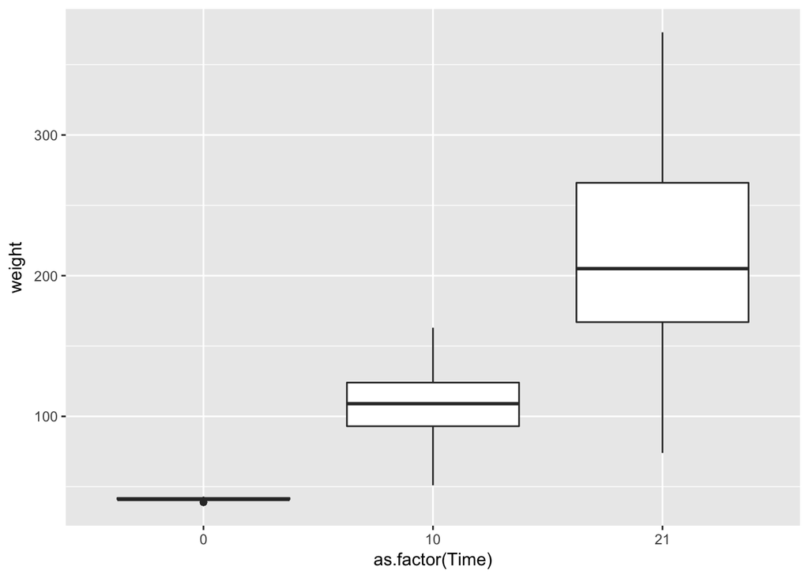

```r
library(ggplot2)
ck3 <- filter(ck,Time %in% c(0,10,21))

ggplot(ck3, aes(x = as.factor(Time), y = weight))+geom_boxplot()
```

From the boxplot above we can learn that the the weights of chicken increse with time on average. But the variations of the weights also increase.

4. How do chicks’ weights compare on different diets? Use facetting and side-by-side boxplots of the previous subset.

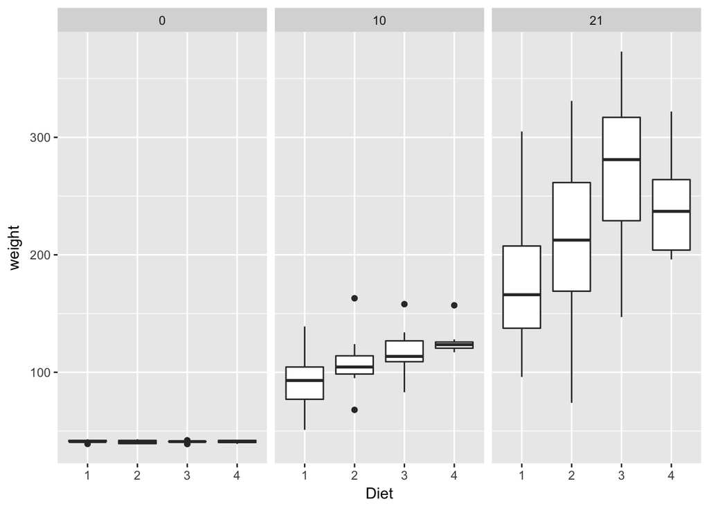

```r
ggplot(ck3, aes(x = Diet, y = weight))+geom_boxplot()+facet_wrap(~factor(Time))
```

On the day 0, there is no difference. On the day 10, diet 3 and 4 are slightly better the the rest. But the differences are not significant. On the day 21, we can see from the boxplot that thhe diet 3 is the best. And diet 2 and 4 are close. While diet 1 is the worst one.

5. How many chicks survive to day 21 on each of the diets? Use facetted barcharts for an answer.

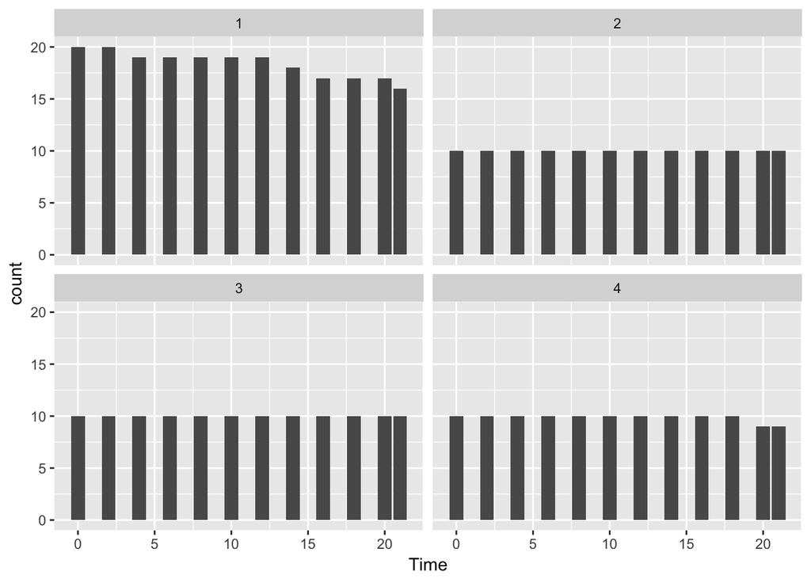

```r
ggplot(ck, aes(x = Time))+geom_bar()+facet_wrap(~Diet)
```

From the figure above, we can find that the numbers of chicks on day 21 are 16, 10, 10, 9 for diet 1, 2, 3, 4 respectively. We can also find that no chick dies under diet 2 and 3.

6. Focus on chicks 10, 25, 35, and 45. Introduce a separate dataset for each of the chicks. For each of them, determine the minimum weight. Introduce a variable `rel.gain` into each dataset that measures the relative gain in weight (weight gain divided by minimum weight). Combine the four data sets into one (use `rbind`). Plot lines to show weight gains over time for each of the chicks. Color by Diet. Interpret the result.

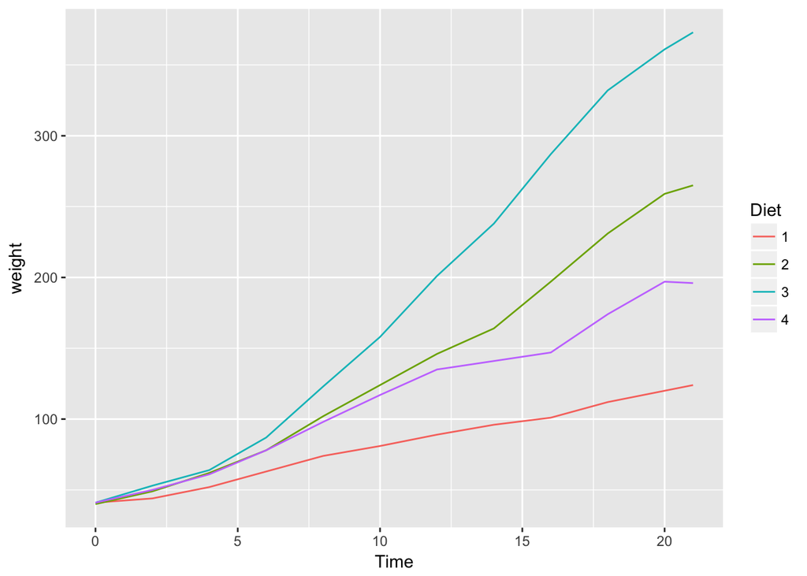

```r
ck10 <- filter(ck, Chick == 10)
ck10$rel.gain <- (ck10$weight-min(ck10$weight))/min(ck10$weight)

ck25 <- filter(ck, Chick == 25)
ck25$rel.gain <- (ck25$weight-min(ck25$weight))/min(ck25$weight)

ck35 <- filter(ck, Chick == 35)
ck35$rel.gain <- (ck35$weight-min(ck35$weight))/min(ck35$weight)

ck45 <- filter(ck, Chick == 45)
ck45$rel.gain <- (ck45$weight-min(ck45$weight))/min(ck45$weight)

cknew <- rbind(ck10, ck25, ck35, ck45)

ggplot(cknew, aes(x = Time, y = weight, color = Diet))+geom_line()
```

We chose one bird from each diet group, and the plot illustrates that the chicken from diet 3 has the fastest growing speed. And the second best is the bird from diet 2, The third is from diet 4 and diet 1 has the worst growing speed.

Due date: the homework is due before class on Thursday.

For the submission: submit your solution in an R Markdown file and (just for insurance) submit the corresponding html file with it.